# Project work: A mini segmentation challenge on BRACS lumen histopathology

**Course**: MSLS / CO4  
**Student**: Michele Pfister  
**Email**: pfistmi5@students.zhaw.ch  
**University**: ZHAW Zurich University of Applied Sciences  
**Semester**: 2nd Semester, SS26  
**Date**: 31.05.2026

## Abstract

This project investigates automatic lumen segmentation in H&E-stained BRACS breast histopathology image patches. A small dataset of 15 image patches was manually segmented and then processed with three reproducible Python approaches: a classical color-deconvolution/morphology pipeline, an HED + watershed refinement, and a pretrained Cellpose model. All automated mask sets are evaluated against the manual masks using the Dice similarity coefficient.

- 1. Dataset
- 2. Preprocessing
- 3. Manual segmentation
- 4. Automated segmentation
- 5. Evaluation
- 6. Discussion
- 7. Reproducibility and deliverables
- 7. Literatur
- 7. Use of AI

## Prerequisites / Setup

The notebook only uses well-maintained Python packages. To run it on another computer, place the notebook in the project folder and install the dependencies from `requirements.txt`. Cellpose downloads a pretrained model the first time it is used.

```
python -m pip install -r requirements.txt
```

All paths below are relative to the folder containing this notebook/project. No user-specific absolute paths are required.

```python
from pathlib import Path
import json
import os
import warnings

import cv2 as cv
import matplotlib.pyplot as plt
import numpy as np
import pandas as pd
from PIL import Image, ImageDraw
from skimage.color import rgb2hed
from skimage.exposure import rescale_intensity
from scipy import ndimage as ndi
from skimage.feature import peak_local_max
from skimage.filters import threshold_otsu
from skimage.morphology import closing, dilation, disk, opening, remove_small_holes, remove_small_objects
from skimage.segmentation import watershed

%matplotlib inline

# Locate the project folder. In normal use, this is the notebook folder.
PROJECT_DIR = Path.cwd()
if not (PROJECT_DIR / "Data").exists():
    candidates = [p for p in PROJECT_DIR.parents if (p / "Data").exists()]
    if candidates:
        PROJECT_DIR = candidates[0]

RAW_DIR = PROJECT_DIR / "Data" / "Data_Original"
PROCESSED_DIR = PROJECT_DIR / "Data" / "Data_Processed"
GEOJSON_DIR = PROJECT_DIR / "geojson"
MANUAL_MASK_DIR = PROJECT_DIR / "manually masked data"
AUTO_MASK_DIR = PROJECT_DIR / "automated_masks"
WATERSHED_MASK_DIR = PROJECT_DIR / "watershed_masks"
CELLPOSE_MASK_DIR = PROJECT_DIR / "cellpose_masks"

for folder in [PROCESSED_DIR, MANUAL_MASK_DIR, AUTO_MASK_DIR, WATERSHED_MASK_DIR, CELLPOSE_MASK_DIR]:
    folder.mkdir(parents=True, exist_ok=True)

image_paths = sorted(RAW_DIR.glob("*.png"))
print(f"Project folder resolved. Notebook is using: {PROJECT_DIR.name}")
print(f"Raw images found: {len(image_paths)}")
print(f"Manual GeoJSON files found: {len(list(GEOJSON_DIR.glob('*.geojson')))}")

# Keep Cellpose downloads in a project-local cache instead of a user-specific home folder.
os.environ.setdefault("CELLPOSE_LOCAL_MODELS_PATH", str(PROJECT_DIR / "cellpose_model_cache"))
warnings.filterwarnings("ignore", message="Sparse invariant checks.*")

def read_image(image_path: Path, flags: int = cv.IMREAD_COLOR) -> np.ndarray:
    """Read an image and fail clearly if OpenCV cannot load it."""
    image = cv.imread(str(image_path), flags)
    if image is None:
        raise FileNotFoundError(f"Could not read image: {image_path}")
    return image


def read_rgb_image(image_path: Path) -> np.ndarray:
    """Read an image with OpenCV and convert it from BGR to RGB."""
    return cv.cvtColor(read_image(image_path), cv.COLOR_BGR2RGB)
```

```
Project folder resolved. Notebook is using: CO4
Raw images found: 15
Manual GeoJSON files found: 15
```

## 1. Dataset

The dataset used in this project consists of H&E-stained histopathology image patches derived from breast tissue whole-slide images associated with the BRACS breast cancer histopathology dataset. The selected subset contains 15 PNG images with a size of 299 x 299 pixels in RGB color space.

The structures of interest are glandular lumen regions. In H&E histology, lumen structures often appear as bright or nearly empty spaces enclosed by darker epithelial and nuclear tissue. These structures are biologically relevant because glandular architecture and lumen morphology can change in benign, atypical, and malignant breast tissue.

The image subset was obtained from the Kaggle dataset `BRACS_histopath` by Babita Dhanwal, which is publicly listed under the Apache 2.0 license:

https://www.kaggle.com/datasets/babitadhanwal/bracs-histopath

A limitation is that the Kaggle subset provides relatively little acquisition metadata. The images are nevertheless suitable for this mini segmentation challenge because they show clear H&E breast tissue morphology and visible lumen-like structures. The selected patches visually resemble representative BRACS material described in the original BRACS publication by Brancati et al. (Brancati, 2022).

```python
dataset_overview = pd.DataFrame({
    "image": [p.name for p in image_paths],
    "width": [read_image(p).shape[1] for p in image_paths],
    "height": [read_image(p).shape[0] for p in image_paths],
})
dataset_overview
```

|  | image | width | height |
| --- | --- | --- | --- |
| 0 | BRACS_1286_N_40.png | 299 | 299 |
| 1 | BRACS_1937_N_11.png | 299 | 299 |
| 2 | BRACS_1937_N_15.png | 299 | 299 |
| 3 | BRACS_1937_N_6.png | 299 | 299 |
| 4 | BRACS_1937_N_7.png | 299 | 299 |
| 5 | BRACS_1937_N_8.png | 299 | 299 |
| 6 | BRACS_1937_PB_5.png | 299 | 299 |
| 7 | BRACS_1940_PB_2.png | 299 | 299 |
| 8 | BRACS_1941_PB_12.png | 299 | 299 |
| 9 | BRACS_1942_PB_3.png | 299 | 299 |
| 10 | BRACS_1943_PB_22.png | 299 | 299 |
| 11 | BRACS_1945_N_11.png | 299 | 299 |
| 12 | BRACS_1945_N_22.png | 299 | 299 |
| 13 | BRACS_1952_PB_3.png | 299 | 299 |
| 14 | BRACS_305_N_5.png | 299 | 299 |

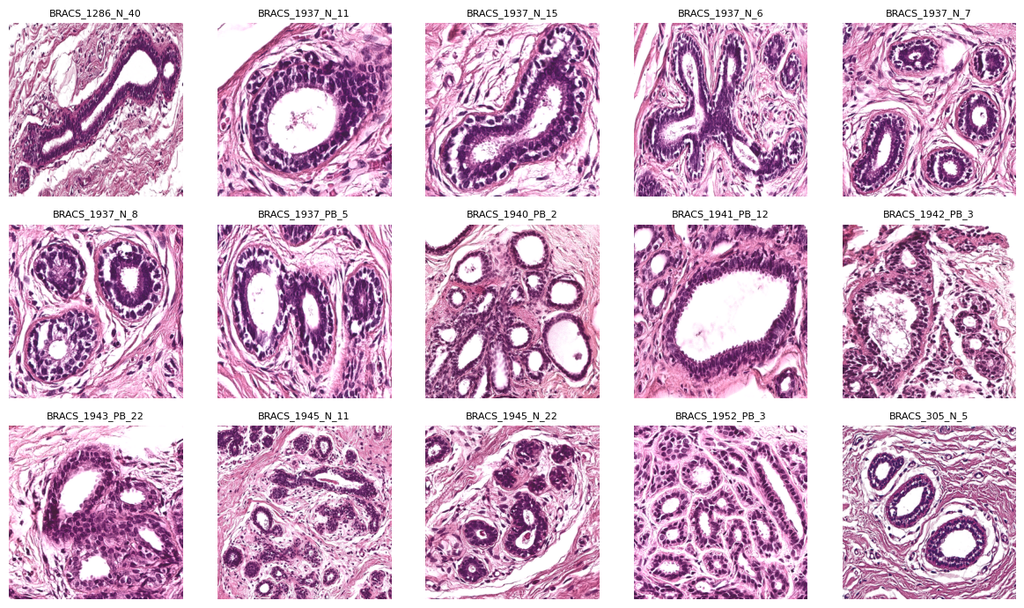

```python
fig, axes = plt.subplots(3, 5, figsize=(12, 7))
for ax, image_path in zip(axes.ravel(), image_paths):
    img = read_rgb_image(image_path)
    ax.imshow(img)
    ax.set_title(image_path.stem, fontsize=8)
    ax.axis("off")
plt.tight_layout()
plt.show()
```

## 2. Preprocessing

The preprocessing has two purposes: first, to create reproducible processed image files for the deliverables; second, to prepare useful intermediate representations for segmentation.

The steps are:

1. Load each RGB image from `Data/Data_Original`.
2. Convert RGB to grayscale for simple intensity visualization.
3. Convert RGB to HED stain space. The HED representation separates hematoxylin and eosin-like stain contributions, which helps distinguish darker cellular tissue from bright lumen spaces.
4. Smooth the hematoxylin channel with a small Gaussian filter.
5. Apply Otsu thresholding and morphology to create a simple tissue-wall preprocessing mask.
6. Save RGB, grayscale, and preprocessing masks to `Data/Data_Processed`.

```python
def preprocess_image(image_path: Path) -> dict[str, np.ndarray]:
    """Load one image and create grayscale, HED, threshold, and wall-mask outputs."""
    img_bgr = read_image(image_path)

    img_rgb = cv.cvtColor(img_bgr, cv.COLOR_BGR2RGB)
    gray = cv.cvtColor(img_rgb, cv.COLOR_RGB2GRAY)

    hed = rgb2hed(img_rgb)
    hematoxylin = -hed[:, :, 0]
    hematoxylin = rescale_intensity(hematoxylin, out_range=(0, 255)).astype(np.uint8)
    blurred = cv.GaussianBlur(hematoxylin, (3, 3), 0)

    _, wall_mask = cv.threshold(blurred, 0, 255, cv.THRESH_BINARY + cv.THRESH_OTSU)
    kernel = np.ones((3, 3), np.uint8)
    wall_mask = cv.morphologyEx(wall_mask, cv.MORPH_CLOSE, kernel)

    preprocessing_mask = np.full_like(gray, 255)
    preprocessing_mask[wall_mask > 0] = 0

    return {
        "rgb": img_rgb,
        "gray": gray,
        "hematoxylin": hematoxylin,
        "blurred": blurred,
        "wall_mask": wall_mask,
        "preprocessing_mask": preprocessing_mask,
    }

preprocessed = {}
for image_path in image_paths:
    result = preprocess_image(image_path)
    preprocessed[image_path.stem] = result

    cv.imwrite(str(PROCESSED_DIR / f"{image_path.stem}_rgb.png"), cv.cvtColor(result["rgb"], cv.COLOR_RGB2BGR))
    cv.imwrite(str(PROCESSED_DIR / f"{image_path.stem}_gray.png"), result["gray"])
    cv.imwrite(str(PROCESSED_DIR / f"{image_path.stem}_mask.png"), result["preprocessing_mask"])

print(f"Saved processed files to: {PROCESSED_DIR.relative_to(PROJECT_DIR)}")
```

```
Saved processed files to: Data/Data_Processed
```

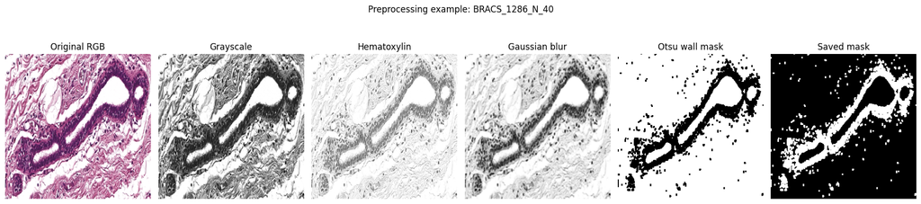

```python
sample_name = image_paths[0].stem
sample = preprocessed[sample_name]

fig, axes = plt.subplots(1, 6, figsize=(18, 4))
for ax, key, title, cmap in [
    (axes[0], "rgb", "Original RGB", None),
    (axes[1], "gray", "Grayscale", "gray"),
    (axes[2], "hematoxylin", "Hematoxylin", "gray"),
    (axes[3], "blurred", "Gaussian blur", "gray"),
    (axes[4], "wall_mask", "Otsu wall mask", "gray"),
    (axes[5], "preprocessing_mask", "Saved mask", "gray"),
]:
    ax.imshow(sample[key], cmap=cmap)
    ax.set_title(title)
    ax.axis("off")

fig.suptitle(f"Preprocessing example: {sample_name}", y=1.05)
plt.tight_layout()
plt.show()
```

The preprocessing improves contrast between dark tissue walls and bright lumen/background-like regions. It is not yet the final automatic segmentation: the final method below uses the same stain-space idea, but specifically extracts lumen candidates as holes enclosed by tissue.

## 3. Manual segmentation

Manual segmentation was performed by outlining lumen structures in QuPath and exporting the annotations as GeoJSON files (Bankhead et al., 2017). The structure of interest was the lumen: bright hollow spaces inside glandular or duct-like tissue regions.

The manual segmentation process was challenging because lumen boundaries were not always clearly defined. Some lumens contained faint staining, others were partially collapsed, and pale stromal regions often resembled empty spaces. Small lumen structures were particularly difficult, as minor changes in polygon boundaries could noticeably affect the final mask. Manual segmentation took around 2 hours when drawn manually, but only about 10 minutes using the magic wand tool.

The code below converts all exported GeoJSON polygons into binary PNG masks in the same image coordinate system as the original 299 x 299 images. White pixels (`255`) represent the manual lumen segmentation and black pixels (`0`) represent background.

```python
def draw_polygon_coordinates(draw: ImageDraw.ImageDraw, coordinates):
    """Draw one GeoJSON polygon, including possible inner rings."""
    if not coordinates:
        return
    exterior = [(float(x), float(y)) for x, y in coordinates[0]]
    draw.polygon(exterior, outline=255, fill=255)

    # Interior rings are holes in the annotation and should be set back to background.
    for interior in coordinates[1:]:
        hole = [(float(x), float(y)) for x, y in interior]
        draw.polygon(hole, outline=0, fill=0)


def geojson_to_mask(geojson_path: Path, image_shape) -> np.ndarray:
    """Convert one QuPath/GeoJSON annotation file to a binary mask."""
    height, width = image_shape[:2]
    mask_image = Image.new("L", (width, height), 0)
    draw = ImageDraw.Draw(mask_image)

    with open(geojson_path, "r", encoding="utf-8") as file:
        data = json.load(file)

    for feature in data.get("features", []):
        geometry = feature.get("geometry", {})
        geometry_type = geometry.get("type")
        coordinates = geometry.get("coordinates", [])

        if geometry_type == "Polygon":
            draw_polygon_coordinates(draw, coordinates)
        elif geometry_type == "MultiPolygon":
            for polygon_coordinates in coordinates:
                draw_polygon_coordinates(draw, polygon_coordinates)

    return np.array(mask_image, dtype=np.uint8)

manual_rows = []
for image_path in image_paths:
    img = read_image(image_path)
    geojson_path = GEOJSON_DIR / f"{image_path.stem}.geojson"
    output_path = MANUAL_MASK_DIR / f"{image_path.stem}_manual_mask.png"

    if not geojson_path.exists():
        manual_rows.append({"image": image_path.stem, "status": "missing geojson"})
        continue

    manual_mask = geojson_to_mask(geojson_path, img.shape)
    cv.imwrite(str(output_path), manual_mask)
    manual_rows.append({
        "image": image_path.stem,
        "status": "saved",
        "foreground_pixels": int((manual_mask > 0).sum()),
    })

pd.DataFrame(manual_rows)
```

|  | image | status | foreground_pixels |
| --- | --- | --- | --- |
| 0 | BRACS_1286_N_40 | saved | 4295 |
| 1 | BRACS_1937_N_11 | saved | 9298 |
| 2 | BRACS_1937_N_15 | saved | 4445 |
| 3 | BRACS_1937_N_6 | saved | 5250 |
| 4 | BRACS_1937_N_7 | saved | 2270 |
| 5 | BRACS_1937_N_8 | saved | 2208 |
| 6 | BRACS_1937_PB_5 | saved | 5498 |
| 7 | BRACS_1940_PB_2 | saved | 15423 |
| 8 | BRACS_1941_PB_12 | saved | 24143 |
| 9 | BRACS_1942_PB_3 | saved | 9172 |
| 10 | BRACS_1943_PB_22 | saved | 5154 |
| 11 | BRACS_1945_N_11 | saved | 2700 |
| 12 | BRACS_1945_N_22 | saved | 1805 |
| 13 | BRACS_1952_PB_3 | saved | 5894 |
| 14 | BRACS_305_N_5 | saved | 3532 |

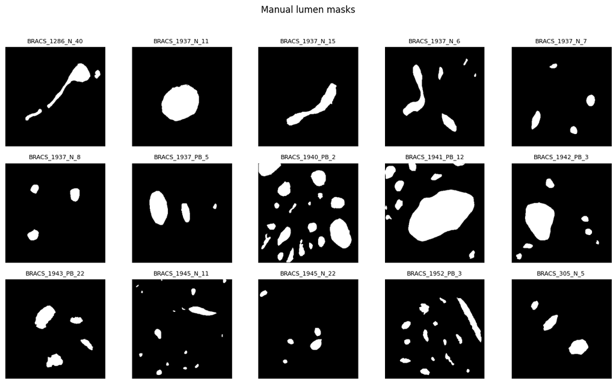

```python
fig, axes = plt.subplots(3, 5, figsize=(12, 7))
for ax, image_path in zip(axes.ravel(), image_paths):
    mask_path = MANUAL_MASK_DIR / f"{image_path.stem}_manual_mask.png"
    manual_mask = read_image(mask_path, cv.IMREAD_GRAYSCALE)
    ax.imshow(manual_mask, cmap="gray")
    ax.set_title(image_path.stem, fontsize=8)
    ax.axis("off")
plt.suptitle("Manual lumen masks", y=1.02)
plt.tight_layout()
plt.show()
```

## 4. Automated segmentation

Three automatic segmentation methods are implemented in Python and compared.

**Method 1: HED morphology.** This is a classical image-processing pipeline. It assumes that lumen structures are relatively bright, weakly stained regions surrounded by darker tissue. The algorithm converts the image to HED stain space, thresholds tissue, fills holes inside the tissue mask, and defines lumen candidates as `filled_tissue AND NOT tissue`.

**Method 2: HED + watershed.** This method starts from the same HED lumen candidates, then uses a distance transform and watershed to split connected lumen candidates into separate regions. A small dilation of the tissue boundary is removed from the lumen candidates to reduce leakage into stained tissue walls. The final output is converted back to a binary mask so it can be compared with the manual masks.

**Method 3: Cellpose + lumen filter.** Cellpose is a pretrained deep-learning segmentation tool (Stringer et al., 2021). The notebook uses the official Cellpose 3 `cyto3` model through the Python API (`cellpose.models.Cellpose(...).eval(...)`). Because Cellpose is trained to segment object-like regions, the image is first converted into a lumen-likelihood image where weakly stained, bright regions become foreground candidates. The Cellpose label image is then filtered using simple color criteria from the original image: retained pixels must be bright and have low saturation, which removes many pale stromal false positives while keeping lumen-like regions (Stringer & Pachitariu, 2025).

The classical parameters were selected empirically for this small dataset. Cellpose is used as a pretrained baseline rather than a model trained specifically for glandular lumens, so it is expected to have limitations on this task.

```python
def automatic_lumen_segmentation(
    image_rgb: np.ndarray,
    threshold_multiplier: float = 1.1,
    max_hole_size: int = 32000,
    min_lumen_size: int = 80,
) -> np.ndarray:
    """Return a binary lumen segmentation mask for one RGB histology image.

    Output format: uint8 mask with lumen pixels = 255 and background = 0.
    """
    hed = rgb2hed(image_rgb)
    hematoxylin = rescale_intensity(hed[:, :, 0], out_range=(0, 1))
    eosin = rescale_intensity(hed[:, :, 1], out_range=(0, 1))

    stain_density = hematoxylin + 0.6 * eosin
    stain_density = (stain_density - stain_density.min()) / (stain_density.max() - stain_density.min() + 1e-8)

    threshold = threshold_otsu(stain_density) * threshold_multiplier
    tissue_mask = stain_density > threshold
    tissue_mask = closing(tissue_mask, disk(2))
    tissue_mask = remove_small_objects(tissue_mask, max_size=80)

    filled_tissue = remove_small_holes(tissue_mask, max_size=max_hole_size)
    lumen_mask = filled_tissue & ~tissue_mask

    lumen_mask = opening(lumen_mask, disk(1))
    lumen_mask = closing(lumen_mask, disk(2))
    lumen_mask = remove_small_objects(lumen_mask, max_size=min_lumen_size)

    return (lumen_mask.astype(np.uint8) * 255)

automatic_rows = []
for image_path in image_paths:
    image_rgb = read_rgb_image(image_path)
    automatic_mask = automatic_lumen_segmentation(image_rgb)
    output_path = AUTO_MASK_DIR / f"{image_path.stem}_automated_mask.png"
    cv.imwrite(str(output_path), automatic_mask)
    automatic_rows.append({
        "image": image_path.stem,
        "hed_morphology_foreground_pixels": int((automatic_mask > 0).sum()),
        "mask_path": str(output_path.relative_to(PROJECT_DIR)),
    })

pd.DataFrame(automatic_rows)
```

|  | image | hed_morphology_foreground_pixels | mask_path |
| --- | --- | --- | --- |
| 0 | BRACS_1286_N_40 | 5969 | automated_masks/BRACS_1286_N_40_automated_mask... |
| 1 | BRACS_1937_N_11 | 14196 | automated_masks/BRACS_1937_N_11_automated_mask... |
| 2 | BRACS_1937_N_15 | 8518 | automated_masks/BRACS_1937_N_15_automated_mask... |
| 3 | BRACS_1937_N_6 | 6124 | automated_masks/BRACS_1937_N_6_automated_mask.png |
| 4 | BRACS_1937_N_7 | 3532 | automated_masks/BRACS_1937_N_7_automated_mask.png |
| 5 | BRACS_1937_N_8 | 6830 | automated_masks/BRACS_1937_N_8_automated_mask.png |
| 6 | BRACS_1937_PB_5 | 2627 | automated_masks/BRACS_1937_PB_5_automated_mask... |
| 7 | BRACS_1940_PB_2 | 22026 | automated_masks/BRACS_1940_PB_2_automated_mask... |
| 8 | BRACS_1941_PB_12 | 24453 | automated_masks/BRACS_1941_PB_12_automated_mas... |
| 9 | BRACS_1942_PB_3 | 13114 | automated_masks/BRACS_1942_PB_3_automated_mask... |
| 10 | BRACS_1943_PB_22 | 14670 | automated_masks/BRACS_1943_PB_22_automated_mas... |
| 11 | BRACS_1945_N_11 | 3659 | automated_masks/BRACS_1945_N_11_automated_mask... |
| 12 | BRACS_1945_N_22 | 2001 | automated_masks/BRACS_1945_N_22_automated_mask... |
| 13 | BRACS_1952_PB_3 | 3064 | automated_masks/BRACS_1952_PB_3_automated_mask... |
| 14 | BRACS_305_N_5 | 13188 | automated_masks/BRACS_305_N_5_automated_mask.png |

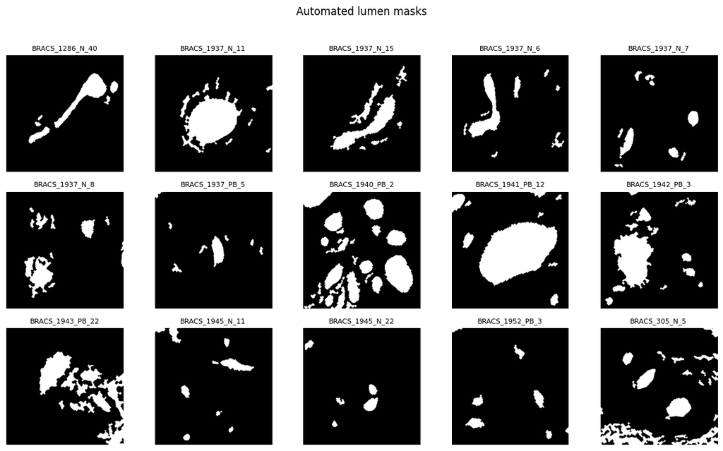

```python
fig, axes = plt.subplots(3, 5, figsize=(12, 7))
for ax, image_path in zip(axes.ravel(), image_paths):
    mask_path = AUTO_MASK_DIR / f"{image_path.stem}_automated_mask.png"
    automatic_mask = read_image(mask_path, cv.IMREAD_GRAYSCALE)
    ax.imshow(automatic_mask, cmap="gray")
    ax.set_title(image_path.stem, fontsize=8)
    ax.axis("off")
plt.suptitle("Automated lumen masks", y=1.02)
plt.tight_layout()
plt.show()
```

### Method 2: HED + watershed

Watershed is useful when several lumen candidates touch or when a candidate region needs to be split into more plausible sub-regions. The method below computes a distance transform inside the HED lumen candidate mask, places markers at local distance maxima, and applies watershed on the negative distance map. The separated regions are then filtered by area and converted to a binary mask.

```python
def hed_lumen_candidate(
    image_rgb: np.ndarray,
    threshold_multiplier: float = 1.1,
    max_hole_size: int = 32000,
    min_lumen_size: int = 80,
):
    """Return the HED stain density, tissue mask, and initial lumen candidates."""
    hed = rgb2hed(image_rgb)
    hematoxylin = rescale_intensity(hed[:, :, 0], out_range=(0, 1))
    eosin = rescale_intensity(hed[:, :, 1], out_range=(0, 1))

    stain_density = hematoxylin + 0.6 * eosin
    stain_density = (stain_density - stain_density.min()) / (stain_density.max() - stain_density.min() + 1e-8)

    threshold = threshold_otsu(stain_density) * threshold_multiplier
    tissue_mask = stain_density > threshold
    tissue_mask = closing(tissue_mask, disk(2))
    tissue_mask = remove_small_objects(tissue_mask, max_size=80)

    filled_tissue = remove_small_holes(tissue_mask, max_size=max_hole_size)
    lumen_candidate = filled_tissue & ~tissue_mask
    lumen_candidate = opening(lumen_candidate, disk(1))
    lumen_candidate = closing(lumen_candidate, disk(2))
    lumen_candidate = remove_small_objects(lumen_candidate, max_size=min_lumen_size)

    return stain_density, tissue_mask, lumen_candidate


def watershed_lumen_segmentation(
    image_rgb: np.ndarray,
    min_marker_distance: int = 8,
    min_region_size: int = 40,
) -> np.ndarray:
    """Segment lumen candidates using HED preprocessing followed by watershed."""
    stain_density, tissue_mask, lumen_candidate = hed_lumen_candidate(image_rgb)

    # Remove pixels immediately adjacent to tissue walls to reduce boundary leakage.
    lumen_candidate = lumen_candidate & ~dilation(tissue_mask, disk(1))

    distance = ndi.distance_transform_edt(lumen_candidate)
    marker_coordinates = peak_local_max(
        distance,
        min_distance=min_marker_distance,
        labels=lumen_candidate,
        exclude_border=False,
    )

    markers = np.zeros(lumen_candidate.shape, dtype=np.int32)
    for marker_id, (row, col) in enumerate(marker_coordinates, start=1):
        markers[row, col] = marker_id

    if markers.max() == 0:
        labels, _ = ndi.label(lumen_candidate)
    else:
        labels = watershed(-distance, markers, mask=lumen_candidate)

    lumen_mask = np.zeros(lumen_candidate.shape, dtype=bool)
    for label_id in range(1, labels.max() + 1):
        region = labels == label_id
        if region.sum() >= min_region_size:
            lumen_mask |= region

    lumen_mask = opening(lumen_mask, disk(1))
    lumen_mask = closing(lumen_mask, disk(2))
    lumen_mask = remove_small_objects(lumen_mask, max_size=min_region_size)
    return (lumen_mask.astype(np.uint8) * 255)


watershed_rows = []
for image_path in image_paths:
    image_rgb = read_rgb_image(image_path)
    watershed_mask = watershed_lumen_segmentation(image_rgb)
    output_path = WATERSHED_MASK_DIR / f"{image_path.stem}_watershed_mask.png"
    cv.imwrite(str(output_path), watershed_mask)
    watershed_rows.append({
        "image": image_path.stem,
        "watershed_foreground_pixels": int((watershed_mask > 0).sum()),
        "mask_path": str(output_path.relative_to(PROJECT_DIR)),
    })

pd.DataFrame(watershed_rows)
```

|  | image | watershed_foreground_pixels | mask_path |
| --- | --- | --- | --- |
| 0 | BRACS_1286_N_40 | 5257 | watershed_masks/BRACS_1286_N_40_watershed_mask... |
| 1 | BRACS_1937_N_11 | 12438 | watershed_masks/BRACS_1937_N_11_watershed_mask... |
| 2 | BRACS_1937_N_15 | 6996 | watershed_masks/BRACS_1937_N_15_watershed_mask... |
| 3 | BRACS_1937_N_6 | 4913 | watershed_masks/BRACS_1937_N_6_watershed_mask.png |
| 4 | BRACS_1937_N_7 | 2761 | watershed_masks/BRACS_1937_N_7_watershed_mask.png |
| 5 | BRACS_1937_N_8 | 5229 | watershed_masks/BRACS_1937_N_8_watershed_mask.png |
| 6 | BRACS_1937_PB_5 | 1904 | watershed_masks/BRACS_1937_PB_5_watershed_mask... |
| 7 | BRACS_1940_PB_2 | 19071 | watershed_masks/BRACS_1940_PB_2_watershed_mask... |
| 8 | BRACS_1941_PB_12 | 23345 | watershed_masks/BRACS_1941_PB_12_watershed_mas... |
| 9 | BRACS_1942_PB_3 | 11177 | watershed_masks/BRACS_1942_PB_3_watershed_mask... |
| 10 | BRACS_1943_PB_22 | 11951 | watershed_masks/BRACS_1943_PB_22_watershed_mas... |
| 11 | BRACS_1945_N_11 | 2997 | watershed_masks/BRACS_1945_N_11_watershed_mask... |
| 12 | BRACS_1945_N_22 | 1621 | watershed_masks/BRACS_1945_N_22_watershed_mask... |
| 13 | BRACS_1952_PB_3 | 2566 | watershed_masks/BRACS_1952_PB_3_watershed_mask... |
| 14 | BRACS_305_N_5 | 9379 | watershed_masks/BRACS_305_N_5_watershed_mask.png |

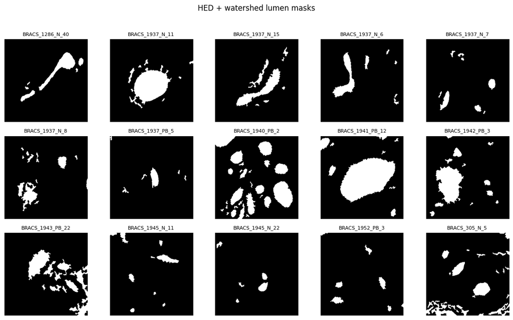

```python
fig, axes = plt.subplots(3, 5, figsize=(12, 7))
for ax, image_path in zip(axes.ravel(), image_paths):
    mask_path = WATERSHED_MASK_DIR / f"{image_path.stem}_watershed_mask.png"
    watershed_mask = read_image(mask_path, cv.IMREAD_GRAYSCALE)
    ax.imshow(watershed_mask, cmap="gray")
    ax.set_title(image_path.stem, fontsize=8)
    ax.axis("off")
plt.suptitle("HED + watershed lumen masks", y=1.02)
plt.tight_layout()
plt.show()
```

### Method 3: Cellpose + lumen filter

The Cellpose input is not the raw RGB image. Instead, the RGB image is transformed into a single-channel lumen-likelihood image by inverting the HED stain-density image. This makes pale lumen-like areas bright and highly stained tissue dark, which better matches Cellpose's object-segmentation assumptions.

A direct binary conversion of all Cellpose objects gave a low Dice score because Cellpose also segmented many non-lumen pale tissue regions. To improve this, the method keeps only Cellpose pixels that are bright and low-saturation in the original image. This makes the Cellpose baseline more specific to lumen-like structures while still using Cellpose as the region proposal method.

```python
from cellpose import models


def create_lumen_likelihood_image(image_rgb: np.ndarray) -> np.ndarray:
    """Create a grayscale image where pale, weakly stained lumen-like regions are bright."""
    hed = rgb2hed(image_rgb)
    hematoxylin = rescale_intensity(hed[:, :, 0], out_range=(0, 1))
    eosin = rescale_intensity(hed[:, :, 1], out_range=(0, 1))
    stain_density = hematoxylin + 0.6 * eosin
    stain_density = (stain_density - stain_density.min()) / (stain_density.max() - stain_density.min() + 1e-8)
    return ((1.0 - stain_density) * 255).astype(np.uint8)


def cellpose_lumen_segmentation(image_rgb: np.ndarray, model) -> np.ndarray:
    """Run Cellpose and retain only bright, low-saturation lumen-like pixels."""
    lumen_likelihood = create_lumen_likelihood_image(image_rgb)
    masks, flows, styles, diameters = model.eval(
        lumen_likelihood,
        channels=[0, 0],
        diameter=55,
        flow_threshold=0.4,
        cellprob_threshold=-2.0,
        min_size=30,
    )

    hsv = cv.cvtColor(image_rgb, cv.COLOR_RGB2HSV)
    saturation = hsv[:, :, 1] / 255.0
    value = hsv[:, :, 2] / 255.0

    lumen_mask = (masks > 0) & (saturation <= 0.12) & (value >= 0.75)
    lumen_mask = opening(lumen_mask, disk(1))
    lumen_mask = closing(lumen_mask, disk(2))
    lumen_mask = remove_small_objects(lumen_mask, max_size=30)
    return (lumen_mask.astype(np.uint8) * 255)


cellpose_model = models.Cellpose(gpu=False, model_type="cyto3")

cellpose_rows = []
for image_path in image_paths:
    image_rgb = read_rgb_image(image_path)
    cellpose_mask = cellpose_lumen_segmentation(image_rgb, cellpose_model)
    output_path = CELLPOSE_MASK_DIR / f"{image_path.stem}_cellpose_mask.png"
    cv.imwrite(str(output_path), cellpose_mask)
    cellpose_rows.append({
        "image": image_path.stem,
        "cellpose_foreground_pixels": int((cellpose_mask > 0).sum()),
        "mask_path": str(output_path.relative_to(PROJECT_DIR)),
    })

pd.DataFrame(cellpose_rows)
```

|  | image | cellpose_foreground_pixels | mask_path |
| --- | --- | --- | --- |
| 0 | BRACS_1286_N_40 | 3617 | cellpose_masks/BRACS_1286_N_40_cellpose_mask.png |
| 1 | BRACS_1937_N_11 | 9659 | cellpose_masks/BRACS_1937_N_11_cellpose_mask.png |
| 2 | BRACS_1937_N_15 | 6637 | cellpose_masks/BRACS_1937_N_15_cellpose_mask.png |
| 3 | BRACS_1937_N_6 | 3005 | cellpose_masks/BRACS_1937_N_6_cellpose_mask.png |
| 4 | BRACS_1937_N_7 | 2734 | cellpose_masks/BRACS_1937_N_7_cellpose_mask.png |
| 5 | BRACS_1937_N_8 | 2447 | cellpose_masks/BRACS_1937_N_8_cellpose_mask.png |
| 6 | BRACS_1937_PB_5 | 5220 | cellpose_masks/BRACS_1937_PB_5_cellpose_mask.png |
| 7 | BRACS_1940_PB_2 | 15248 | cellpose_masks/BRACS_1940_PB_2_cellpose_mask.png |
| 8 | BRACS_1941_PB_12 | 17567 | cellpose_masks/BRACS_1941_PB_12_cellpose_mask.png |
| 9 | BRACS_1942_PB_3 | 5200 | cellpose_masks/BRACS_1942_PB_3_cellpose_mask.png |
| 10 | BRACS_1943_PB_22 | 5793 | cellpose_masks/BRACS_1943_PB_22_cellpose_mask.png |
| 11 | BRACS_1945_N_11 | 3702 | cellpose_masks/BRACS_1945_N_11_cellpose_mask.png |
| 12 | BRACS_1945_N_22 | 2074 | cellpose_masks/BRACS_1945_N_22_cellpose_mask.png |
| 13 | BRACS_1952_PB_3 | 8929 | cellpose_masks/BRACS_1952_PB_3_cellpose_mask.png |
| 14 | BRACS_305_N_5 | 5766 | cellpose_masks/BRACS_305_N_5_cellpose_mask.png |

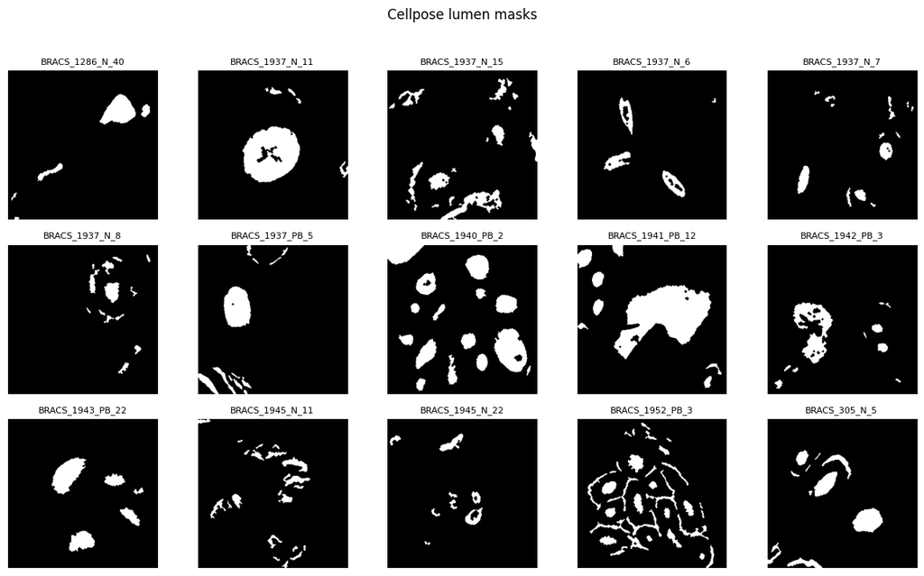

```python
fig, axes = plt.subplots(3, 5, figsize=(12, 7))
for ax, image_path in zip(axes.ravel(), image_paths):
    mask_path = CELLPOSE_MASK_DIR / f"{image_path.stem}_cellpose_mask.png"
    cellpose_mask = read_image(mask_path, cv.IMREAD_GRAYSCALE)
    ax.imshow(cellpose_mask, cmap="gray")
    ax.set_title(image_path.stem, fontsize=8)
    ax.axis("off")
plt.suptitle("Cellpose lumen masks", y=1.02)
plt.tight_layout()
plt.show()
```

## 5. Evaluation

The automatic segmentation methods are evaluated against the manual masks using the Dice similarity coefficient. Dice is commonly used for binary segmentation because it measures spatial overlap while accounting for the size of the masks.

For a predicted mask `A` and a manual ground-truth mask `B`, the Dice score is:

$$ Dice(A, B) = \frac{2 |A \cap B|}{|A| + |B|} $$

A Dice score of 1 means perfect overlap. A Dice score of 0 means no overlap.

```python
def dice_score(mask_a: np.ndarray, mask_b: np.ndarray) -> float:
    """Compute Dice similarity for two binary masks."""
    a = mask_a > 0
    b = mask_b > 0
    denominator = a.sum() + b.sum()
    if denominator == 0:
        return 1.0
    intersection = np.logical_and(a, b).sum()
    return 2.0 * intersection / denominator

method_specs = [
    {
        "method": "HED morphology",
        "folder": AUTO_MASK_DIR,
        "suffix": "_automated_mask.png",
    },
    {
        "method": "HED + watershed",
        "folder": WATERSHED_MASK_DIR,
        "suffix": "_watershed_mask.png",
    },
    {
        "method": "Cellpose + lumen filter",
        "folder": CELLPOSE_MASK_DIR,
        "suffix": "_cellpose_mask.png",
    },
]

results = []
for image_path in image_paths:
    manual_mask = read_image(MANUAL_MASK_DIR / f"{image_path.stem}_manual_mask.png", cv.IMREAD_GRAYSCALE)

    for spec in method_specs:
        predicted_mask = read_image(spec["folder"] / f"{image_path.stem}{spec['suffix']}", cv.IMREAD_GRAYSCALE)
        score = dice_score(predicted_mask, manual_mask)
        results.append({
            "image": image_path.stem,
            "method": spec["method"],
            "dice": score,
            "manual_pixels": int((manual_mask > 0).sum()),
            "predicted_pixels": int((predicted_mask > 0).sum()),
        })

results_df = pd.DataFrame(results)
summary_df = (
    results_df
    .groupby("method")["dice"]
    .agg(mean="mean", std=lambda s: s.std(ddof=1))
    .sort_values("mean", ascending=False)
)

print("Dice summary by method:")
display(summary_df)

results_df.sort_values(["method", "dice"], ascending=[True, False]).reset_index(drop=True)
```

```
Dice summary by method:
```

| method | mean | std |
| --- | --- | --- |
| HED + watershed | 0.685816 | 0.218016 |
| Cellpose + lumen filter | 0.655358 | 0.225626 |
| HED morphology | 0.640740 | 0.220539 |

|  | image | method | dice | manual_pixels | predicted_pixels |
| --- | --- | --- | --- | --- | --- |
| 0 | BRACS_1943_PB_22 | Cellpose + lumen filter | 0.931214 | 5154 | 5793 |
| 1 | BRACS_1937_N_11 | Cellpose + lumen filter | 0.902780 | 9298 | 9659 |
| 2 | BRACS_1940_PB_2 | Cellpose + lumen filter | 0.894721 | 15423 | 15248 |
| 3 | BRACS_1286_N_40 | Cellpose + lumen filter | 0.840243 | 4295 | 3617 |
| 4 | BRACS_1941_PB_12 | Cellpose + lumen filter | 0.821002 | 24143 | 17567 |
| 5 | BRACS_1937_N_7 | Cellpose + lumen filter | 0.762990 | 2270 | 2734 |
| 6 | BRACS_305_N_5 | Cellpose + lumen filter | 0.759518 | 3532 | 5766 |
| 7 | BRACS_1937_N_6 | Cellpose + lumen filter | 0.693882 | 5250 | 3005 |
| 8 | BRACS_1942_PB_3 | Cellpose + lumen filter | 0.660590 | 9172 | 5200 |
| 9 | BRACS_1937_PB_5 | Cellpose + lumen filter | 0.637059 | 5498 | 5220 |
| 10 | BRACS_1945_N_22 | Cellpose + lumen filter | 0.587265 | 1805 | 2074 |
| 11 | BRACS_1952_PB_3 | Cellpose + lumen filter | 0.429603 | 5894 | 8929 |
| 12 | BRACS_1937_N_8 | Cellpose + lumen filter | 0.356606 | 2208 | 2447 |
| 13 | BRACS_1945_N_11 | Cellpose + lumen filter | 0.286161 | 2700 | 3702 |
| 14 | BRACS_1937_N_15 | Cellpose + lumen filter | 0.266739 | 4445 | 6637 |
| 15 | BRACS_1941_PB_12 | HED + watershed | 0.920738 | 24143 | 23345 |
| 16 | BRACS_1286_N_40 | HED + watershed | 0.889238 | 4295 | 5257 |
| 17 | BRACS_1945_N_22 | HED + watershed | 0.880911 | 1805 | 1621 |
| 18 | BRACS_1942_PB_3 | HED + watershed | 0.860485 | 9172 | 11177 |
| 19 | BRACS_1937_N_11 | HED + watershed | 0.854711 | 9298 | 12438 |
| 20 | BRACS_1940_PB_2 | HED + watershed | 0.829941 | 15423 | 19071 |
| 21 | BRACS_1937_N_7 | HED + watershed | 0.801034 | 2270 | 2761 |
| 22 | BRACS_1937_N_15 | HED + watershed | 0.749934 | 4445 | 6996 |
| 23 | BRACS_1937_N_6 | HED + watershed | 0.733248 | 5250 | 4913 |
| 24 | BRACS_1945_N_11 | HED + watershed | 0.698613 | 2700 | 2997 |
| 25 | BRACS_305_N_5 | HED + watershed | 0.547130 | 3532 | 9379 |
| 26 | BRACS_1937_N_8 | HED + watershed | 0.505042 | 2208 | 5229 |
| 27 | BRACS_1943_PB_22 | HED + watershed | 0.442678 | 5154 | 11951 |
| 28 | BRACS_1937_PB_5 | HED + watershed | 0.315861 | 5498 | 1904 |
| 29 | BRACS_1952_PB_3 | HED + watershed | 0.257683 | 5894 | 2566 |
| 30 | BRACS_1941_PB_12 | HED morphology | 0.911598 | 24143 | 24453 |
| 31 | BRACS_1945_N_22 | HED morphology | 0.903311 | 1805 | 2001 |
| 32 | BRACS_1286_N_40 | HED morphology | 0.835347 | 4295 | 5969 |
| 33 | BRACS_1942_PB_3 | HED morphology | 0.802297 | 9172 | 13114 |
| 34 | BRACS_1937_N_11 | HED morphology | 0.791266 | 9298 | 14196 |
| 35 | BRACS_1940_PB_2 | HED morphology | 0.768298 | 15423 | 22026 |
| 36 | BRACS_1937_N_7 | HED morphology | 0.739400 | 2270 | 3532 |
| 37 | BRACS_1945_N_11 | HED morphology | 0.690675 | 2700 | 3659 |
| 38 | BRACS_1937_N_6 | HED morphology | 0.679269 | 5250 | 6124 |
| 39 | BRACS_1937_N_15 | HED morphology | 0.678547 | 4445 | 8518 |
| 40 | BRACS_1937_N_8 | HED morphology | 0.464705 | 2208 | 6830 |
| 41 | BRACS_305_N_5 | HED morphology | 0.422488 | 3532 | 13188 |
| 42 | BRACS_1943_PB_22 | HED morphology | 0.381961 | 5154 | 14670 |
| 43 | BRACS_1937_PB_5 | HED morphology | 0.298585 | 5498 | 2627 |
| 44 | BRACS_1952_PB_3 | HED morphology | 0.243358 | 5894 | 3064 |

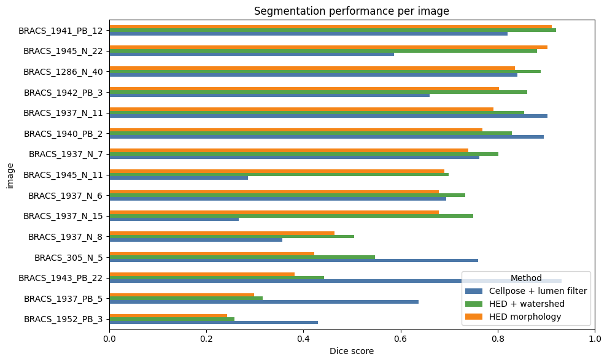

```python
pivot_scores = results_df.pivot(index="image", columns="method", values="dice")
ordered_images = pivot_scores["HED morphology"].sort_values().index
pivot_scores = pivot_scores.loc[ordered_images]

fig, ax = plt.subplots(figsize=(10, 6))
pivot_scores.plot(kind="barh", ax=ax, color=["#4C78A8", "#54A24B", "#F58518"])
ax.set_xlim(0, 1)
ax.set_xlabel("Dice score")
ax.set_title("Segmentation performance per image")
ax.legend(title="Method")
plt.tight_layout()
plt.show()
```

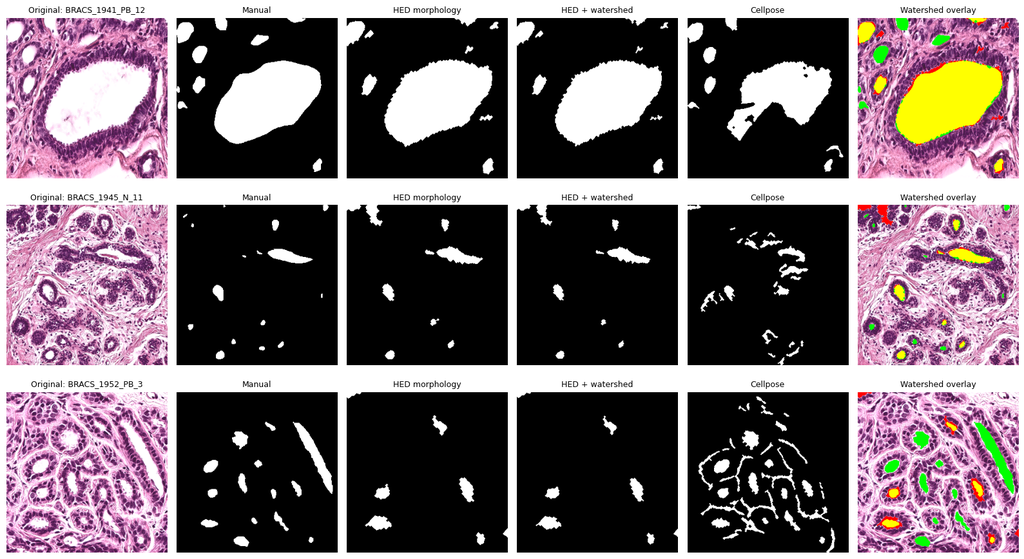

```python
def make_overlay(image_rgb: np.ndarray, manual_mask: np.ndarray, predicted_mask: np.ndarray) -> np.ndarray:
    """Green = manual mask, red = predicted mask, yellow = overlap."""
    overlay = image_rgb.copy()
    manual = manual_mask > 0
    predicted = predicted_mask > 0

    overlay[manual] = [0, 255, 0]
    overlay[predicted] = [255, 0, 0]
    overlay[manual & predicted] = [255, 255, 0]
    return overlay

classical_scores = results_df[results_df["method"] == "HED morphology"].sort_values("dice", ascending=False)
selected_names = [
    classical_scores.iloc[0]["image"],
    classical_scores.iloc[len(classical_scores) // 2]["image"],
    classical_scores.iloc[-1]["image"],
]

fig, axes = plt.subplots(len(selected_names), 6, figsize=(16, 9))
for row, name in enumerate(selected_names):
    image_rgb = read_rgb_image(RAW_DIR / f"{name}.png")
    manual_mask = read_image(MANUAL_MASK_DIR / f"{name}_manual_mask.png", cv.IMREAD_GRAYSCALE)
    classical_mask = read_image(AUTO_MASK_DIR / f"{name}_automated_mask.png", cv.IMREAD_GRAYSCALE)
    watershed_mask = read_image(WATERSHED_MASK_DIR / f"{name}_watershed_mask.png", cv.IMREAD_GRAYSCALE)
    cellpose_mask = read_image(CELLPOSE_MASK_DIR / f"{name}_cellpose_mask.png", cv.IMREAD_GRAYSCALE)

    for ax, image, title, cmap in [
        (axes[row, 0], image_rgb, f"Original: {name}", None),
        (axes[row, 1], manual_mask, "Manual", "gray"),
        (axes[row, 2], classical_mask, "HED morphology", "gray"),
        (axes[row, 3], watershed_mask, "HED + watershed", "gray"),
        (axes[row, 4], cellpose_mask, "Cellpose", "gray"),
        (axes[row, 5], make_overlay(image_rgb, manual_mask, watershed_mask), "Watershed overlay", None),
    ]:
        ax.imshow(image, cmap=cmap)
        ax.set_title(title, fontsize=9)
        ax.axis("off")

plt.tight_layout()
plt.show()
```

## 6. Discussion

The HED + watershed method achieves the strongest average Dice score on this dataset, but its improvement over the HED morphology baseline is modest. This makes sense because watershed is not a completely separate detector here; it refines the same HED-derived lumen candidates by separating connected regions and trimming pixels near tissue walls.

The HED morphology method remains a strong and simple baseline. It performs best when lumen regions are clearly enclosed by dark epithelial tissue and have strong contrast against the surrounding structures. The watershed variant can improve cases where candidate regions touch tissue walls or need better separation, but it can also remove true lumen pixels if the tissue-boundary trimming is too aggressive.

The Cellpose baseline is useful as a comparison because it applies a pretrained deep-learning segmentation method without task-specific training. A direct conversion of all Cellpose labels performed poorly because Cellpose is designed for cellular or object-like structures, while glandular lumens are empty spaces defined by surrounding tissue. Adding the brightness and low-saturation filter improves the score substantially, but the method can still miss irregular lumen boundaries or include pale non-lumen regions.

All automatic methods fail or become less accurate when the assumptions are violated. Pale stromal tissue can be mistaken for lumen, fragmented epithelial borders can prevent correct hole detection, and very small lumen structures may be removed by morphology filters. Images with many small glandular spaces are particularly difficult because the algorithms may merge, miss, or over-segment them.

Manual segmentation remains more anatomically informed because a human can use context to decide whether a bright region is truly lumen. However, it is slow, subjective, and sensitive to boundary ambiguity. The automated methods are faster and reproducible, but they lack biological understanding and depend strongly on staining, contrast, and parameter choices.

Future improvements could include stain normalization, adaptive parameter selection, region features to reject pale stroma, or a supervised segmentation model such as U-Net trained directly on lumen masks. A larger train/test split would also make the evaluation less optimistic than tuning and testing on the same small collection.

## 7. Reproducibility and deliverables

This folder contains the required project elements:

- `CO4_Project_Michele_Pfister.ipynb` / this notebook file
- `requirements.txt` with all non-standard Python packages
- `Data/Data_Original` with the raw image patches
- `Data/Data_Processed` with RGB, grayscale, and preprocessing-mask outputs
- `manually masked data` with manual binary masks
- `automated_masks` with the HED morphology automated masks
- `watershed_masks` with the HED + watershed automated masks
- `cellpose_masks` with the Cellpose automated masks
- `geojson` with the exported manual annotation files

Cellpose stores downloaded model weights in `cellpose_model_cache` when the notebook is run. This cache is not a deliverable and can be regenerated automatically from the dependency.

To export the notebook after running all cells, use Jupyter's `File -> Save and Export Notebook As...` menu, or run:

```
jupyter nbconvert --to html --execute "CO4_Project_Michèle_Pfister.ipynb"
```

## 8. Literatur

Nadia Brancati, Anna Maria Anniciello, Pushpak Pati, Daniel Riccio, Giosuè Scognamiglio, Guillaume Jaume, Giuseppe De Pietro, Maurizio Di Bonito, Antonio Foncubierta, Gerardo Botti, Maria Gabrani, Florinda Feroce, Maria Frucci, BRACS: A Dataset for BReAst Carcinoma Subtyping in H&E Histology Images, Database, Volume 2022, 2022, baac093, https://doi.org/10.1093/database/baac093

Bankhead, P., Loughrey, M.B., Fernández, J.A. et al. QuPath: Open source software for digital pathology image analysis. Sci Rep 7, 16878 (2017). https://doi.org/10.1038/s41598-017-17204-5

Stringer, C., Wang, T., Michaelos, M. et al. Cellpose: a generalist algorithm for cellular segmentation. Nat Methods 18, 100–106 (2021). https://doi.org/10.1038/s41592-020-01018-x

Stringer, C., Pachitariu, M. Cellpose3: one-click image restoration for improved cellular segmentation. Nat Methods 22, 592–599 (2025). https://doi.org/10.1038/s41592-025-02595-5

## 9. Use of AI

Generative AI tools were used throughout the development of this project as supportive assistants for coding, debugging, conceptual understanding, and scientific communication.

ChatGPT (OpenAI) was used to:

- assist with Python programming and debugging,
- explain image-processing and segmentation concepts,
- support implementation of preprocessing and segmentation workflows using libraries such as OpenCV, scikit-image, and Cellpose,
- help interpret intermediate segmentation results,
- improve code readability and notebook structure,
- assist in drafting and refining report sections, presentation structure, and scientific wording,
- and support the formulation of discussions, limitations, and future work sections.

AI-generated suggestions were critically reviewed, modified, and validated before integration into the final project. All methodological choices, parameter selections, interpretation of results, evaluation of segmentation performance, and final conclusions were made by the student.

No AI tool was used to automatically generate the final scientific conclusions or independently conduct the project analysis.